# R Notebook

Roman Alberto Velez Jimenez

```r
library(tidyverse)
```

# Ejercicio 1: Verosimilitud

## Pregunta 1.1: Qué es esta función

Esta función devuelve la log verosimilitud de una distribución binomial $X ~ \text{Bin}(n, p)$ para el parámetro $p$ donde $X$ es si hay o no error, y $p$ representa la probabilidad de ese error. Para estimarlo, se observan $N$ datos, de los cuales $N_{\text{err}}$ contienen error.

```r
# create log likelihood
bin_loglike <- function(n, n_err){
  n_corr <- n - n_err
  log_verosim <- function(p){
    n_err * log(p) + n_corr * log(1-p)
  }
}

# create some sim
tibble(x = seq(0, 1, 0.001)) |>
  mutate(loglike = map_dbl(x, bin_loglike(n = 100, n_err = 25))) |>
  ggplot(aes(x, loglike)) +
  geom_line()
```

[output not shown]

## Pregunta 1.2: Construir con $N = 500$ y $N_{\text{err}} = 121$

De qué parámetros depende esta ultima función? **Respuesta:** *Está función depende de $N_{err}$, puesto que $N$ es fija. Los datos observados son $N_{err}$, que en este caso es 121.*

[figure not shown]

## 1.3: Usar MV

Bajo la muestra $X = N_{\text{err}} = 121$ para $N = 500$, se encontrará $p$ vía máxima verosomilitud, es decir optimizando `loglike` para $X$ y $N$ fija.

```r
# optimize
p_mlike <- optimize(
  f = bin_loglike(n = 500, n_err = 121),
  interval = c(0, 1), # support of p
  maximum = TRUE # maximization
)

# print
print(str_glue("Maxima verosimilitud, p: {round(p_mlike[[1]], 4)}"))
```

```
Maxima verosimilitud, p: 0.242
```

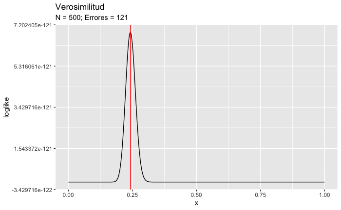

```r
# create likelihood
bin_like <- function(n, n_err){
  n_corr <- n - n_err
  log_verosim <- function(p){
    exp(n_err * log(p) + n_corr * log(1-p))
  }
}

# create some sim
tibble(x = seq(0, 1, 0.001)) |>
  mutate(loglike = map_dbl(x, bin_like(n = 500, n_err = 121))) |>
  ggplot(aes(x, loglike)) +
  geom_line() +
  geom_vline(xintercept = p_mlike$maximum, color = "red") +
  ggtitle("Verosimilitud", "N = 500; Errores = 121")
```

## 1.4: $N_{err} = 317$

Se reptie el ejercicio para 317 errores.

```r
# optimize
p_mlike <- optimize(
  f = bin_loglike(n = 500, n_err = 317),
  interval = c(0, 1), # support of p
  maximum = TRUE # maximization
)

# print
print(str_glue("Maxima verosimilitud, p: {round(p_mlike[[1]], 4)}"))
```

```
Maxima verosimilitud, p: 0.634
```

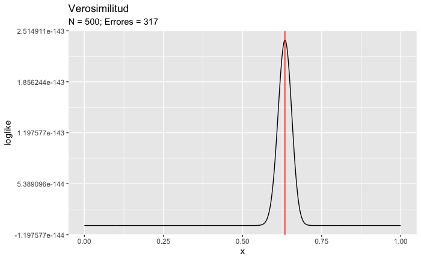

```r
# create some sim
tibble(x = seq(0, 1, 0.001)) |>
  mutate(loglike = map_dbl(x, bin_like(n = 500, n_err = 317))) |>
  ggplot(aes(x, loglike)) +
  geom_line() +
  geom_vline(xintercept = p_mlike$maximum, color = "red") +
  ggtitle("Verosimilitud", "N = 500; Errores = 317")
```

# Pregunta 2: Normal

## 2.1: Escribir la verosimilitud para una muestra de tamaño $n$

### Verosmilitud

La verosimilitud para $X ~ \sim \mathcal{N}(\mu, \sigma)$ está dada por:
$$\mathcal{L}(\mu, \sigma^2; \underline{x}) =
\prod_{i=1}^{n} \frac{1}{\sqrt{2\pi\sigma^2}} \exp\left(-\frac{(x_{i} -
\mu)^2}{2\sigma^2}\right).$$

### Log Versomilitud

Por consiguiente, la log verosimilitud está dada por
$$\ell(\mu, \sigma^2; \underline{x}) =
\sum_{i}^{n}-\frac{1}{2}\log(2\pi\sigma^2) - \frac{(x_{i} -
\mu)^2}{2\sigma^2}. = -n\log(\sigma) - \sum_{i}^{n}\frac{(x_{i} -
\mu)^2}{2\sigma^2}$$
Nótese que $\sqrt{2 \pi}$ desparece de $\ell$ ya que es una constante.

## 2.2: Estimar $\mu$, $\sigma$

Para ejemplificar MV para una normal, generamos su media y desviación estándar de forma aleatoria.

```r
set.seed(1234)
m <- runif(1, 5, 10) # media entre 5 y 10
desv_est <- runif(1, 0, 2) # desviación estándar entre 0 y 2

#simulamos una muestra con la que trabajaremos.
x <- rnorm(150, mean = m, sd = desv_est)

# revisar datos
qplot(x, geom = "histogram") + ggtitle("Histograma de la muestra X")
```

[output not shown]

Mediante el método plug-in, encontramos sus parámetros

```r
xmean_plugin <- mean(x)
xsigma_plugin <- sd(x)

cat(str_glue("media plug in: {xmean_plugin}"))
```

```
media plug in: 5.45362032577995
```

```r
cat("\n")
```

```r
cat(str_glue("sigma plug in: {xsigma_plugin}"))
```

```
sigma plug in: 1.18967352410231
```

Mediante MV encontramos sus parámetros, fija la muestra $\underline{x}$.

```r
# create log likelihood
normal_loglike <- function(x){
  n <- length(x)
  log_verosim <- function(params){
    - n * log(params[2]) - sum((x - params[1])^(2) / (2 * params[2]^(2))) # 1: mu, 2: sigma
  }
}

loglike_normx <- normal_loglike(x)

# estimate mu & sigma
normal_params_std <- optim(
  par = c(0, 1), # standard normal
  fn = loglike_normx,
  control = list(fnscale = -1, maxit = 1000), # fn = -1 --> maximize
  method = "Nelder-Mead"
)
cat(str_glue("media mv in: {normal_params_std$par[1]}"))
```

```
media mv in: 5.45371324724823
```

```r
cat("\n")
```

```r
cat(str_glue("sigma mv in: {normal_params_std$par[2]}"))
```

```
sigma mv in: 1.18586985947739
```

Los valores reales son

```r
cat(str_glue("media real in: {m}"))
```

```
media real in: 5.56851705652662
```

```r
cat("\n")
```

```r
cat(str_glue("sigma real in: {desv_est}"))
```

```
sigma real in: 1.24459880962968
```